# R Notebook

```r
options(repos = c(CRAN = "https://cran.rstudio.com"))
```

```r
install.packages("readxl")
```

| Name | ID |
| --- | --- |
| Taif alrubeaan | 442202301 |
| Raghad Alboqami | 442200455 |
| Leena Alzahrani | 443200847 |
| Sarah Alghanim | 442201747 |

## The goal of collecting this dataset

our goal is to Identify whether the chances of of a heart attack occurrence is high or low for the patient

#classification and clustering goal

Classification: We will classify target people into different groups based on appearance of muilty symptoms of Heart attack disease .This will allow us to predict the people who target to have heart attack based on certain factors .

Clustering: We will create a set of clusters for people who have similar symptoms. This will allow us to identify groups of people who are have the similar symptoms and target to have heart attack .

We believe that by using these data mining tasks, we can build a model that can accurately predict the people target to have heart attack.

## 1 Problem

Recently, Cardiovascular diseases rate has been increased, which leads death globally. Early detection of the symptoms is important to prevent the disease from fully developing and reduce premature mortality. In our project, we will study and analyze patients’ data that will help us well in identifying symptoms that you don’t recognize as a sign of a heart disease and help many people to take precautions by predicting the possibility of having a Heart attack.

## 2 Data Mining Task

In our project we will use two data mining tasks to help us predict the possibility of having cardiovascular diseases which are classification and clustering. For classification we will train our model to be able to classify if the patient has cardiovascular diseases or not using (target) class based on a set of medical examinations like blood pressure, serum cholesterol , ST depression, etc. For the clustering our model will create a set of clusters for the patient who have similar characteristics, then these clusters will be used to predict new patients’ results.

## General information

[output not shown]

Class label: -target of Heart Attack accurrance -not target of Heart Attack accurrance

## view dataset:

```r
#install.packages("readxl")
library(readxl)
dataset <- read_excel("C:/Users/ragha/OneDrive/سطح المكتب/New folder/Heart Attack Data Set.xlsx")
View(dataset)
```

| Summary of dataset: |
| --- |

```r
nrow(dataset)
```

```
## [1] 303
```

```r
ncol(dataset)
```

```
## [1] 14
```

```r
summary(dataset$age)
```

```
##    Min. 1st Qu.  Median    Mean 3rd Qu.    Max.
##   29.00   47.50   55.00   54.37   61.00   77.00
```

```r
summary(dataset$cp)
```

```
##    Min. 1st Qu.  Median    Mean 3rd Qu.    Max.
##   0.000   0.000   1.000   0.967   2.000   3.000
```

```r
summary(dataset$trestbps)
```

```
##    Min. 1st Qu.  Median    Mean 3rd Qu.    Max.
##    94.0   120.0   130.0   131.6   140.0   200.0
```

```r
summary(dataset$chol)
```

```
##    Min. 1st Qu.  Median    Mean 3rd Qu.    Max.
##   126.0   211.0   240.0   246.3   274.5   564.0
```

```r
summary(dataset$oldpeak)
```

```
##    Min. 1st Qu.  Median    Mean 3rd Qu.    Max.
##    0.00    0.00    0.80    1.04    1.60    6.20
```

```r
summary(dataset$thalach)
```

```
##    Min. 1st Qu.  Median    Mean 3rd Qu.    Max.
##    71.0   133.5   153.0   149.6   166.0   202.0
```

```r
summary(dataset$slope)
```

```
##    Min. 1st Qu.  Median    Mean 3rd Qu.    Max.
##   0.000   1.000   1.000   1.399   2.000   2.000
```

```r
summary(dataset$ca)
```

```
##    Min. 1st Qu.  Median    Mean 3rd Qu.    Max.
##  0.0000  0.0000  0.0000  0.7294  1.0000  4.0000
```

```r
summary(dataset$thal)
```

```
##    Min. 1st Qu.  Median    Mean 3rd Qu.    Max.
##   0.000   2.000   2.000   2.314   3.000   3.000
```

## Missing values and Null values

```r
 is.na(dataset)
```

[output not shown]

[output cut: 593 more lines]

```r
sum(is.na(dataset))
```

```
## [1] 0
```

The output is false and 0 this indicates that the element in our dataset is not missing

Graphs

Boxplot

`## Warning: package 'ggplot2' was built under R version 4.3.2`

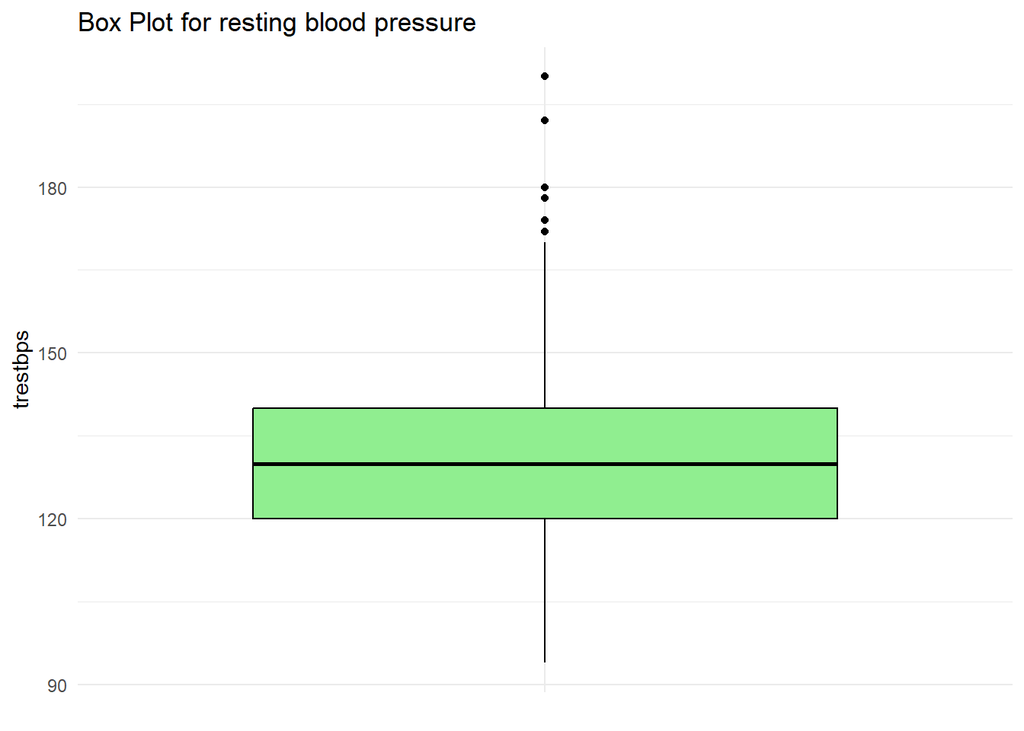

the Box Plot provides valuable insights into the distribution of resting blood pressure between 94- 200, highlighting the high blood pressure experienced by participants and the presence of potential outliers. In this example, any blood pressure below 94 or above 172 BPM would be considered an outlier.

`r ggplot(data = dataset, aes(x = "", y = thalach)) + geom_boxplot(fill = "lightpink", color = "black") + labs( title = "Box Plot for heart rate achieved ", y = "heart rate", x = NULL # Remove x-axis label (since we only have one category) ) + theme_minimal()`

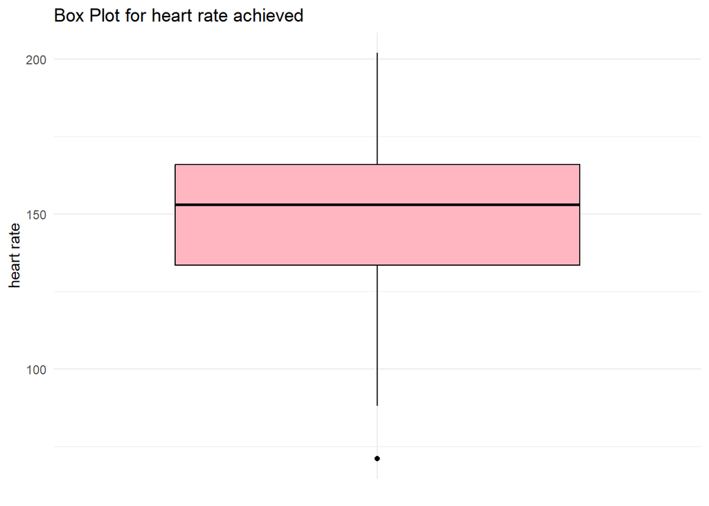

`r ggplot(data = dataset, aes(x = "", y = oldpeak)) + geom_boxplot(fill = "purple", color = "black") + labs( title = "Box Plot for ST depression", y = " ST depressione", x = NULL # Remove x-axis label (since we only have one category) ) + theme_minimal()`

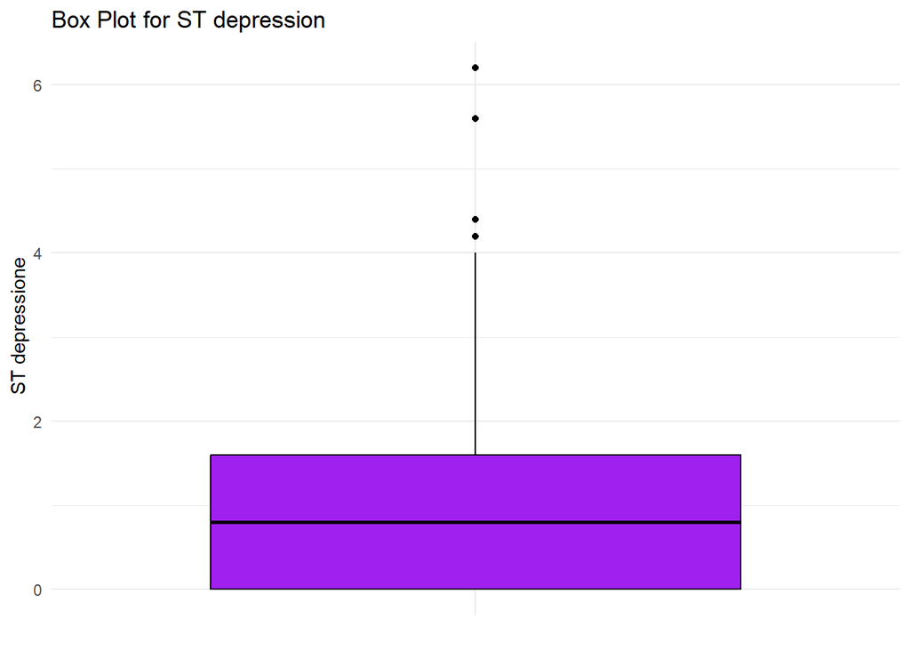

`r ggplot(data = dataset, aes(x = "", y =chol)) + geom_boxplot(fill = "lightyellow", color = "black") + labs( title = "Box Plot for cholestero", y = "chol", x = NULL # Remove x-axis label (since we only have one category) ) + theme_minimal()`

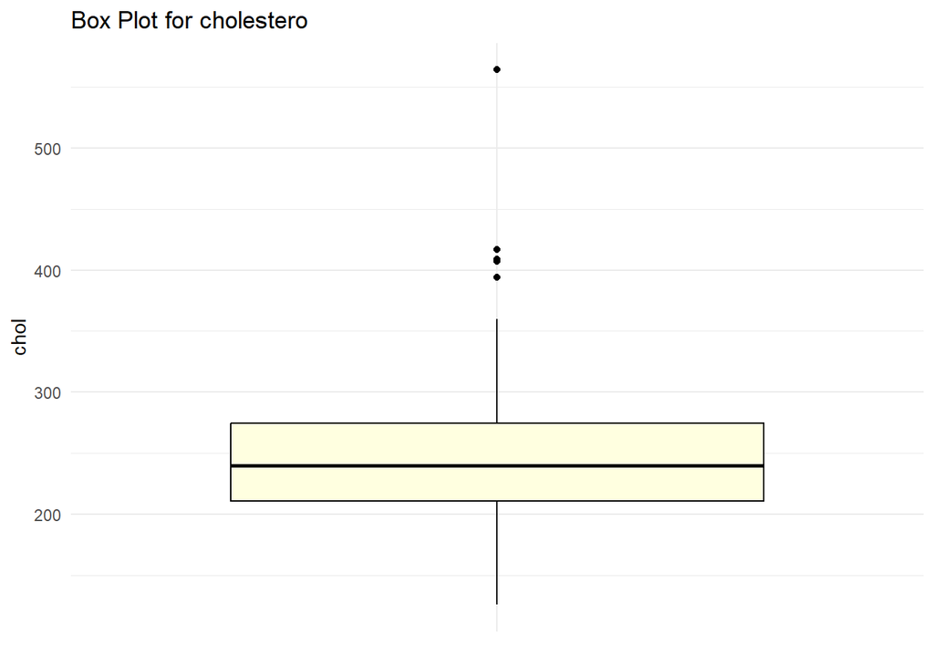

we can also detect summary of each attribute from the box plot , and we use box plot to detect the outlier.

Histogram

`r hist(dataset$chol)`

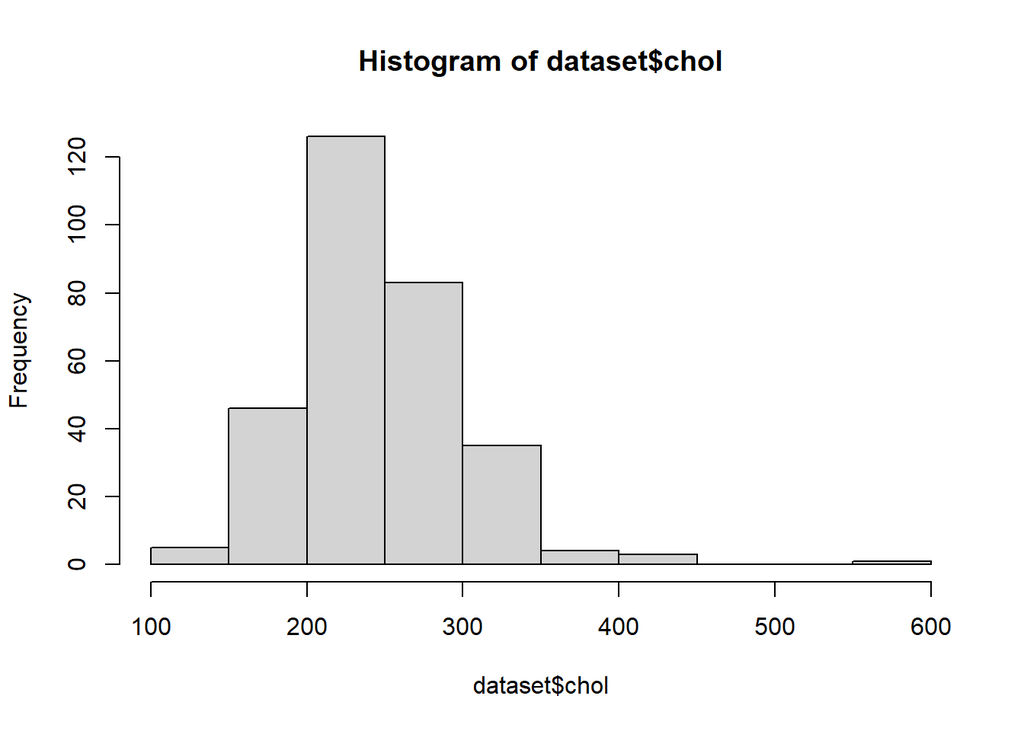

The graph represents the frequency of cholesterol in the data set. After observing the values, we concluded that most of the values fall in the range higher than the normal range, as the normal range falls between 125-200.

Scatter plot

`r library(ggplot2) gg <- ggplot(dataset, aes(x=chol, y=trestbps)) + geom_point(aes(col=target, size=oldpeak)) + labs(subtitle="trestbps Vs chol", y="trestbps", x="chol", title="Scatterplot", caption = "Source: midwest", bins = 30) plot(gg)`

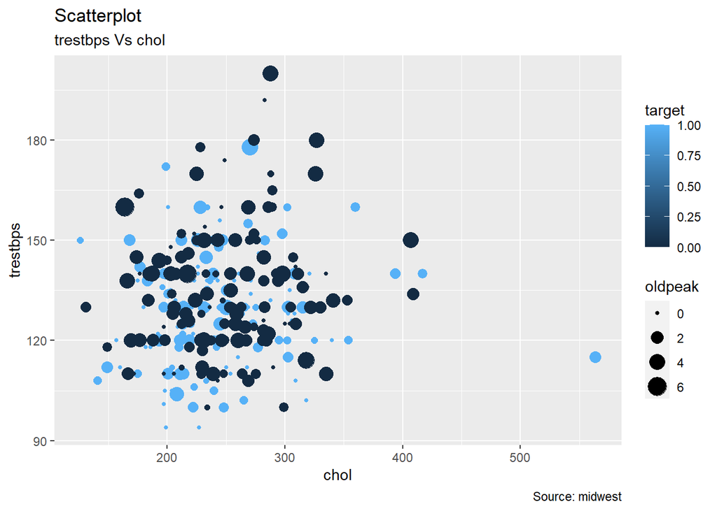

Bar plot There is no point in using bar plots because the frequency of one symptom (ex: high blood pressure alone ) is not enough to decide whether the patients are likely to have a heart attack or not

## outliers:

Detecting the outliers:

```r
  boxplot.stats (dataset$chol)$out
```

```
## [1] 417 564 394 407 409
```

```r
  boxplot.stats (dataset$trestbps)$out
```

```
## [1] 172 178 180 180 200 174 192 178 180
```

```r
  boxplot.stats (dataset$oldpeak)$out
```

```
## [1] 4.2 6.2 5.6 4.2 4.4
```

```r
  boxplot.stats (dataset$thalach)$out
```

```
## [1] 71
```

Removing the outliers:

```r
outliers <- boxplot (dataset$chol, plot=FALSE) $out
 dataset <- dataset [-which(dataset$chol %in% outliers),]
 boxplot.stats (dataset$chol) $out
```

```
## numeric(0)
```

```r
normalize <- function(x) {
  return((x - min(x)) / (max(x) - min(x)))
}

dataset$trestbps <- normalize(dataset$trestbps)
dataset$chol <- normalize(dataset$chol)
dataset$thalach <- normalize(dataset$thalach)
dataset$oldpeak <- normalize(dataset$oldpeak)
dataset$cp <- normalize(dataset$cp)
dataset$oldpeak <- normalize(dataset$oldpeak)
dataset$slope <- normalize(dataset$slope)
```

| feature selection |
| --- |
| we did not applly feature selection beacause the number of attribute is small and we will neeed them. |

## print the final preprocessed dataset

```r
print(dataset)
```

```
## # A tibble: 298 × 14
##      age   sex    cp trestbps  chol   fbs restecg thalach exang oldpeak slope
##    <dbl> <dbl> <dbl>    <dbl> <dbl> <dbl>   <dbl>   <dbl> <dbl>   <dbl> <dbl>
##  1    63     1 1        0.481 0.457     1       0   0.603     0  0.371    0
##  2    37     1 0.667    0.340 0.530     0       1   0.885     0  0.565    0
##  3    41     0 0.333    0.340 0.333     0       0   0.771     0  0.226    1
##  4    56     1 0.333    0.245 0.470     0       1   0.817     0  0.129    1
##  5    57     0 0        0.245 0.974     0       1   0.702     1  0.0968   1
##  6    57     1 0        0.434 0.282     0       1   0.588     0  0.0645   0.5
##  7    56     0 0.333    0.434 0.718     0       0   0.626     0  0.210    0.5
##  8    44     1 0.333    0.245 0.585     0       1   0.779     0  0        1
##  9    52     1 0.667    0.736 0.312     1       1   0.695     0  0.0806   1
## 10    57     1 0.667    0.528 0.179     0       1   0.786     0  0.258    1
## # ℹ 288 more rows
## # ℹ 3 more variables: ca <dbl>, thal <dbl>, target <dbl>
```

#clustering Clustering is an unsupervised learning method and it is the process of arranging a set of objects so that the objects that are in the same cluster are more comparable to those in other clusters. There will not be a class label since clustering is an unsupervised learning method. we are going to partition our data using k-means by trying three different k-means values ( 2,3 and 4 means clusters). In all three trials, we will calculate the average silhouette ,total within-cluster sum of square and the BCubed precision and recall.

##About packages and methods: We used K-means methods to form the clusters. For plots, we used fviz_cluster. For evaluation, we used fviz_silhouette and fviz_nbclust to calculate the silhouette value and cluster,factoextra,NbClust and for visualizing dendrogram we use fviz_dend. We also used a method to calculate Bcubes percision and recall.

Optimal number of clusters:

```r
# Install packages if they are not already installed
if (!require("factoextra")) install.packages("factoextra")
if (!require("cluster")) install.packages("cluster")
if (!require("NbClust")) install.packages("NbClust")
```

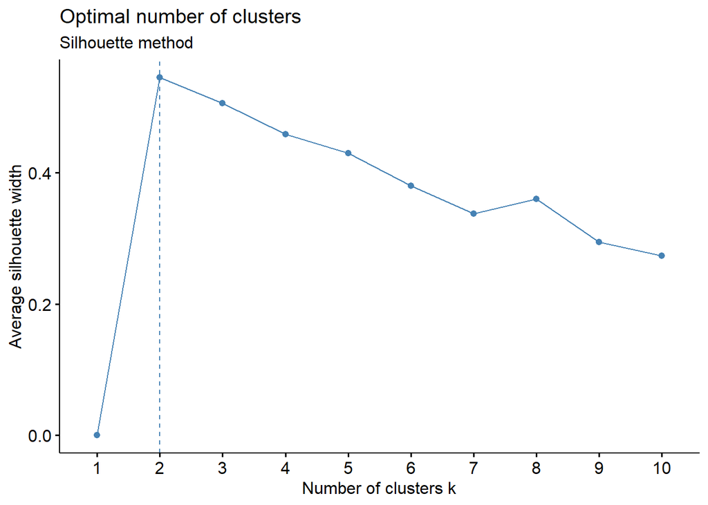

```r
# Load necessary libraries
library(factoextra)
library(cluster)
library(NbClust)


oldDataset<-dataset
dataset=dataset[,-14]

fviz_nbclust(dataset, kmeans, method = "silhouette")+labs(subtitle ="Silhouette method")
```

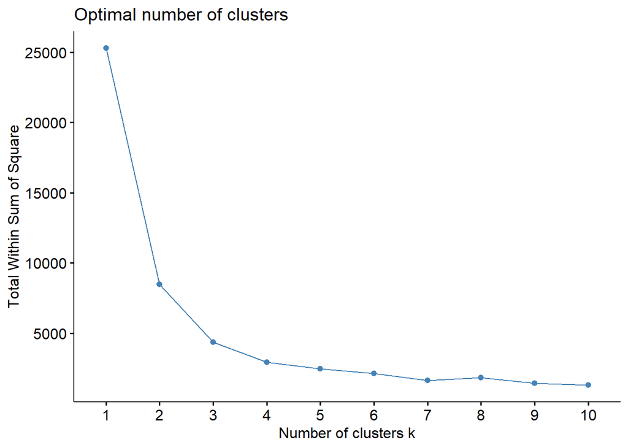

```r
fviz_nbclust(dataset, kmeans, method = "wss")
```

k-means clustring k=2:

```r
set.seed(8953)
dataset=scale(dataset)
kmeans.result <- kmeans(dataset, 2)
# print the clusterng result
kmeans.result
```

```
## K-means clustering with 2 clusters of sizes 103, 195
##
## Cluster means:
##          age        sex         cp   trestbps        chol         fbs
## 1  0.4666272  0.1778915 -0.6946707  0.2348119  0.13919079  0.07628041
## 2 -0.2464749 -0.0939632  0.3669286 -0.1240289 -0.07352129 -0.04029170
##       restecg    thalach      exang    oldpeak      slope         ca       thal
## 1 -0.11637635 -0.8772157  0.8278724  0.7405667 -0.6822723  0.5691607  0.4149900
## 2  0.06147058  0.4633498 -0.4372864 -0.3911711  0.3603797 -0.3006336 -0.2191999
##
## Clustering vector:
##   [1] 2 2 2 2 2 2 2 2 2 2 2 2 2 2 2 2 2 1 2 2 2 2 2 1 2 2 2 2 2 2 2 2 2 2 2 2 2
##  [38] 2 2 2 2 1 2 2 2 2 2 2 2 2 2 1 2 2 2 2 2 2 2 2 2 2 2 2 2 2 2 2 2 2 2 2 2 2
##  [75] 2 2 2 2 2 2 2 2 2 2 2 2 2 2 2 2 2 2 2 1 2 2 2 2 1 2 2 2 2 2 2 2 2 2 2 2 2
## [112] 2 2 2 2 2 2 1 2 2 2 2 2 2 2 2 1 2 2 2 2 2 2 2 2 1 1 2 2 2 2 2 2 2 2 2 2 2
## [149] 1 2 2 2 2 2 2 1 2 2 2 2 2 2 1 1 1 1 1 2 2 2 2 1 1 1 2 1 1 1 1 2 2 1 2 1 1
## [186] 2 2 1 1 1 1 2 1 2 1 1 2 2 1 1 1 1 2 1 1 1 2 2 1 2 1 1 1 1 1 1 1 1 2 1 1 1
## [223] 1 1 2 1 2 1 1 1 1 2 2 1 1 2 1 1 1 1 1 2 1 2 1 1 1 1 1 2 1 1 1 1 2 1 2 1 1
## [260] 1 1 1 2 1 1 2 2 1 2 1 2 1 2 2 1 1 2 2 2 1 1 2 2 1 1 2 1 1 2 1 1 1 1 1 2 1
## [297] 1 2
##
## Within cluster sum of squares by cluster:
## [1] 1256.225 2008.083
##  (between_SS / total_SS =  15.5 %)
##
## Available components:
##
## [1] "cluster"      "centers"      "totss"        "withinss"     "tot.withinss"
## [6] "betweenss"    "size"         "iter"         "ifault"
```

visualize clustering:

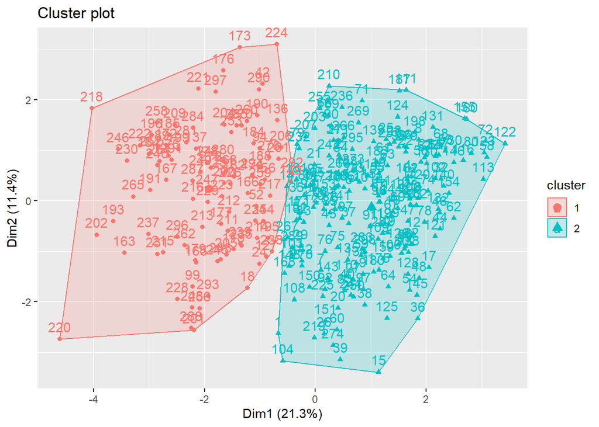

```r
#install.packages("factoextra")
library(factoextra)
fviz_cluster(kmeans.result, data = dataset)
```

K=2: As we can see from the image, there are two clusters with very little to almost no overlapping. And the data is put into two categories, which is what we want knowing the ground truth.

Total within-cluster-sum of square:

```r
kmeans.result$tot.withinss
```

```
## [1] 3264.308
```

[output not shown]

## k=2 model gives us the highest quality of clusters since we were able to reach the precision of 0.70 and recall of 0.72 which is considered high. 0.70 precision indicates that our cluster is leaning towards purity and most of the objects in the same cluster truly belong to The same category (target/ not target of heart attack). 0.72 recall tells us that our data is accurately clustered meaning that a lot of the objects that are from the same category are assign to the same cluster.

k-means clustring k=3:

```r
set.seed(8953)
dataset=scale(dataset)
kmeans.result <- kmeans(dataset, 3)
# print the clusterng result
kmeans.result
```

```
## K-means clustering with 3 clusters of sizes 43, 98, 157
##
## Cluster means:
##          age        sex         cp    trestbps         chol        fbs
## 1  0.2872791  0.1074161  0.2319247  0.43730956  0.002642585  2.3986154
## 2  0.4905931  0.1753146 -0.4944569  0.02997535  0.031164551 -0.3867926
## 3 -0.3849116 -0.1388517  0.2451211 -0.13848341 -0.020176797 -0.4155082
##      restecg     thalach       exang     oldpeak      slope         ca
## 1 -0.1807945  0.02265125  0.04245351  0.02046833 -0.1246271  0.3649212
## 2 -0.1090274 -0.89777216  0.75397955  0.75210648 -0.6838736  0.3737780
## 3  0.1175723  0.55418897 -0.48226431 -0.47507372  0.4610101 -0.3332602
##         thal
## 1 -0.0863170
## 2  0.3120398
## 3 -0.1711355
##
## Clustering vector:
##   [1] 1 3 3 3 3 3 3 3 1 3 3 3 3 2 1 3 3 2 3 3 3 3 3 1 3 3 1 3 1 3 3 3 3 2 2 1 3
##  [38] 3 3 3 3 2 3 3 3 3 3 3 3 3 3 2 3 3 3 3 3 3 3 1 3 3 3 1 3 2 3 3 3 3 3 3 3 3
##  [75] 3 1 3 1 2 3 3 3 1 3 3 1 3 2 1 3 3 1 3 2 1 3 1 3 2 3 1 3 2 1 3 3 3 3 1 3 3
## [112] 3 3 3 3 3 3 2 3 3 3 3 3 3 3 3 2 3 3 3 3 3 3 1 1 2 2 3 3 3 3 2 3 3 3 3 3 2
## [149] 2 3 3 3 3 3 3 2 3 3 3 3 3 3 2 2 2 2 1 1 3 3 3 2 2 1 3 2 2 2 2 3 2 2 3 2 2
## [186] 3 3 2 2 2 2 2 2 3 1 2 3 3 2 2 1 2 3 2 2 2 3 3 2 3 2 1 1 2 1 2 1 2 1 1 2 2
## [223] 2 2 3 2 3 1 2 2 2 3 3 2 2 3 2 2 2 2 2 3 2 3 2 2 1 1 2 3 2 2 2 2 3 1 3 2 2
## [260] 2 2 2 3 2 2 3 2 2 3 2 3 2 3 1 2 2 1 1 3 2 2 3 3 2 2 3 2 1 3 2 2 2 1 2 3 1
## [297] 2 3
##
## Within cluster sum of squares by cluster:
## [1]  538.350 1097.407 1385.619
##  (between_SS / total_SS =  21.7 %)
##
## Available components:
##
## [1] "cluster"      "centers"      "totss"        "withinss"     "tot.withinss"
## [6] "betweenss"    "size"         "iter"         "ifault"
```

visualize clustering

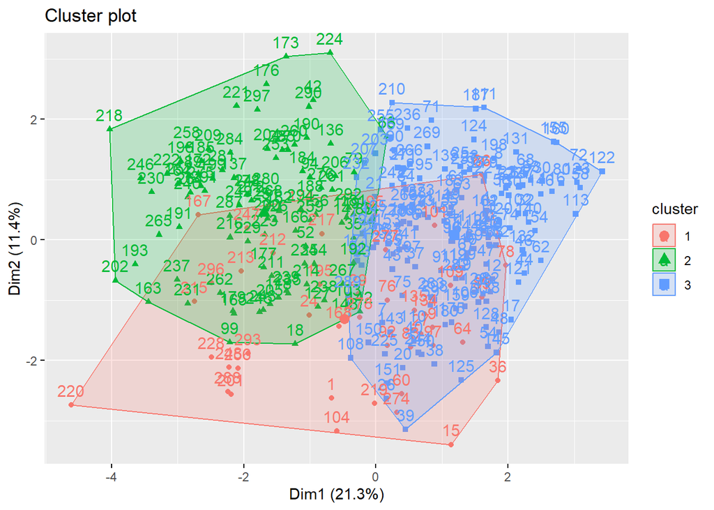

```r
#install.packages("factoextra")
library(factoextra)
fviz_cluster(kmeans.result, data = dataset)
```

K=3: as we can see from the image, there are 3 clusters, which means our data has been put into 3 categories, there is a lot overlapping so the clusters aren’t very clear.

Total within-cluster-sum of square:

```r
kmeans.result$tot.withinss
```

```
## [1] 3021.376
```

[output not shown]

## k=3 model gives us the precision of 0.63 and recall of 0.51. 0.63 precision indicates that our cluster is not very pure although a lot of the objects in the same cluster truly belong to The same category (target/ not target of heart attack) also The value is not very far from k = 2,but its not enough to say that its mostly pure. 0.51 recall tells us that only about half of our data is accurately clustered meaning that about half of the objects that are from the same category are assigned to the same cluster, which is not very good.

k-means clustring k=4:

```r
set.seed(8953)
dataset=scale(dataset)
kmeans.result <- kmeans(dataset, 4)
# print the clusterng result
kmeans.result
```

```
## K-means clustering with 4 clusters of sizes 42, 80, 69, 107
##
## Cluster means:
##            age         sex         cp    trestbps        chol        fbs
## 1  0.315690598  0.09421365  0.2367504  0.48902577  0.02701606  2.3986154
## 2  0.416690212  0.36387425 -0.7091255  0.05798766  0.14705451 -0.3803316
## 3 -0.007571997 -1.50568654  0.2537919 -0.11701550  0.07680778 -0.4155082
## 4 -0.430577143  0.66192017  0.2735971 -0.15985071 -0.17008198 -0.3892080
##       restecg     thalach       exang     oldpeak      slope         ca
## 1 -0.20607094  0.01653354  0.06010298  0.04206335 -0.1505821  0.3904815
## 2 -0.14153700 -0.95687265  0.86836077  0.84407530 -0.7115003  0.5436529
## 3  0.16410087  0.20801026 -0.39085394 -0.43659744  0.2158616 -0.4381590
## 4  0.08088766  0.57479155 -0.42078753 -0.36605105  0.4518693 -0.2771915
##          thal
## 1 -0.11522270
## 2  0.45478427
## 3 -0.50364313
## 4  0.02998119
##
## Clustering vector:
##   [1] 1 4 3 4 3 4 3 4 1 4 4 3 4 2 1 3 3 3 4 3 4 4 4 1 4 3 1 4 1 3 4 4 4 4 3 1 4
##  [38] 3 3 3 4 2 3 4 4 4 4 3 3 3 4 2 3 3 4 4 4 4 3 1 4 4 4 1 3 4 3 4 3 4 4 4 4 3
##  [75] 3 1 4 1 4 4 4 3 1 3 4 4 3 3 1 4 4 1 3 2 1 4 1 4 2 3 1 4 3 1 3 3 3 3 1 3 4
## [112] 4 3 4 4 3 3 2 4 3 3 3 3 4 3 3 3 3 3 4 4 3 3 1 1 2 2 3 4 3 3 3 4 3 3 4 4 4
## [149] 3 4 3 3 3 4 4 2 4 4 3 4 4 4 2 2 2 2 1 1 4 4 4 2 2 1 4 2 2 2 2 3 4 2 4 2 2
## [186] 4 4 2 2 2 2 4 2 4 1 2 4 4 2 2 1 2 4 2 2 2 4 4 2 4 2 1 1 3 1 2 1 2 1 1 2 2
## [223] 2 2 4 2 4 1 2 2 2 4 4 2 2 4 2 3 2 2 2 4 2 4 2 2 1 1 2 4 2 2 2 3 4 1 4 2 2
## [260] 2 2 2 4 2 2 4 4 2 4 2 4 2 4 1 2 2 1 1 4 2 2 4 4 2 2 4 2 1 4 2 2 3 1 2 4 1
## [297] 2 3
##
## Within cluster sum of squares by cluster:
## [1] 524.1004 840.5818 549.9314 893.7696
##  (between_SS / total_SS =  27.3 %)
##
## Available components:
##
## [1] "cluster"      "centers"      "totss"        "withinss"     "tot.withinss"
## [6] "betweenss"    "size"         "iter"         "ifault"
```

visualize clustering

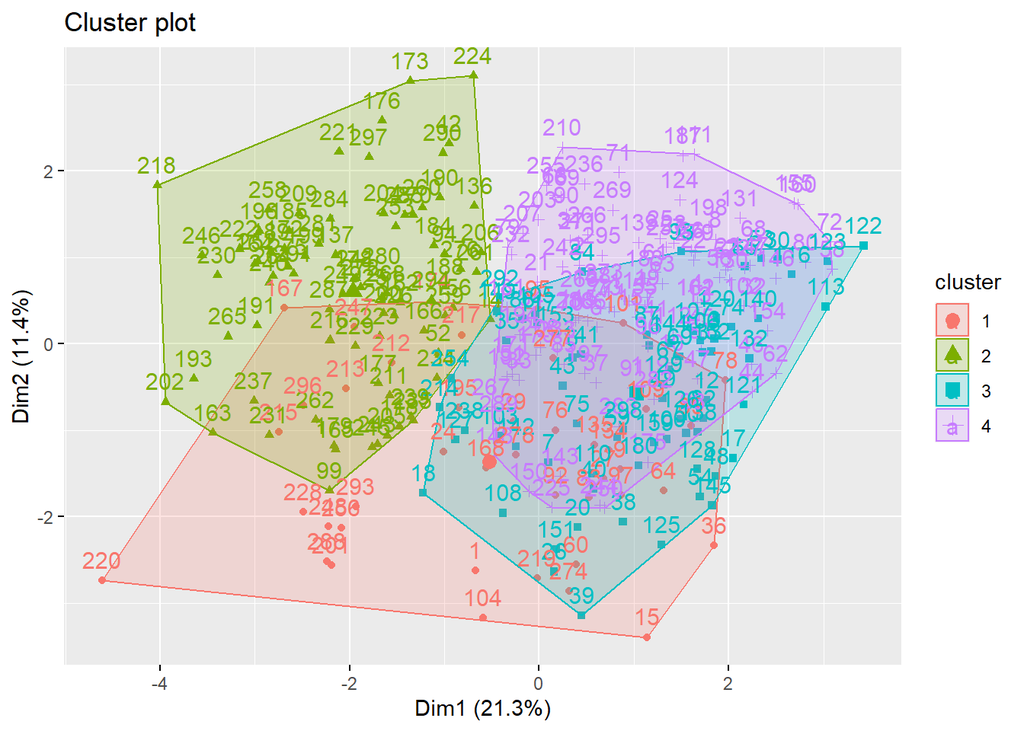

```r
#install.packages("factoextra")
library(factoextra)
fviz_cluster(kmeans.result, data = dataset)
```

K=4: as we can see from the image, there are 4 clusters that aren’t very good since there is a lot of overlapping, so we cant identify the 4 categories clearly and come up with a good conclusion regarding them

Total within-cluster-sum of square:

```r
kmeans.result$tot.withinss
```

```
## [1] 2808.383
```

[output not shown]

## k=4 model gives us the lowest quality of clusters since we were only able to reach the precision of 0.67 and recall of 0.36. 0.67 precision indicates that our cluster is not very pure although a lot of the objects in the same cluster truly belong to The same category (target/ not target of heart attack),but its not enough to say that its mostly pure. 0.36 recall tells us that our data is not accurately clustered meaning that most of the objects that are from the same category are not assigned to the same cluster, and that is not good..

Hierarchical Clustering:

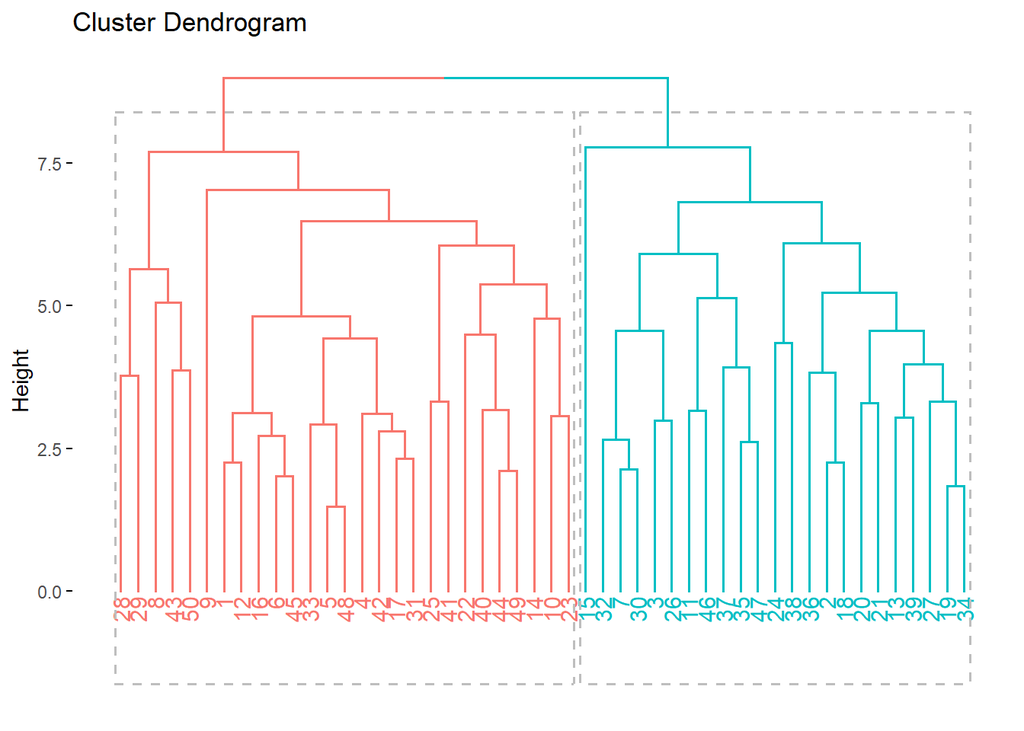

```r
set.seed(2835)
# draw a sample of 40 records from the USArrests data, so that the clustering plot will not be over crowded
idx <- sample(1:dim(dataset)[1], 50)
dataset2 <- dataset[idx, ]
## hiercrchical clustering
library(factoextra)
hc.cut <- hcut(dataset2, k = 2, hc_method = "complete") # Computes Hierarchical Clustering and Cut the Tree


# Visualize dendrogram
fviz_dend(hc.cut,rect = TRUE)  #logical value specifying whether to add a rectangle around groups.
```

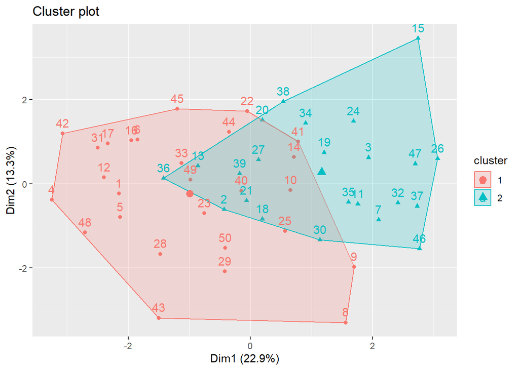

```r
# Visualize cluster
fviz_cluster(hc.cut, ellipse.type = "convex")
```

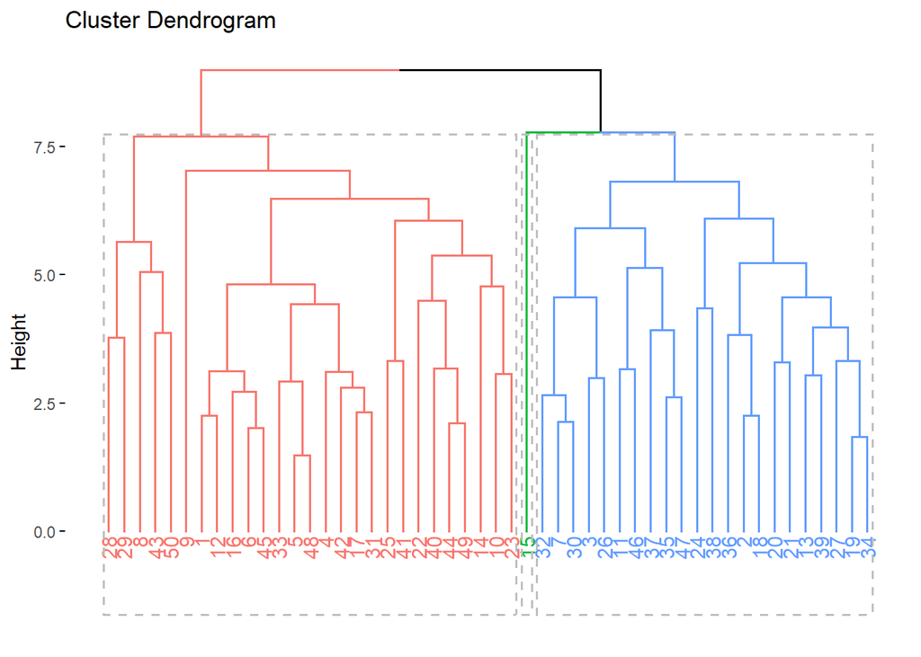

```r
set.seed(2835)
# draw a sample of 40 records from the USArrests data, so that the clustering plot will not be over crowded
idx <- sample(1:dim(dataset)[1], 50)
dataset2 <- dataset[idx, ]
## hiercrchical clustering
library(factoextra)
hc.cut <- hcut(dataset2, k = 3, hc_method = "complete") # Computes Hierarchical Clustering and Cut the Tree


# Visualize dendrogram
fviz_dend(hc.cut,rect = TRUE)  #logical value specifying whether to add a rectangle around groups.
```

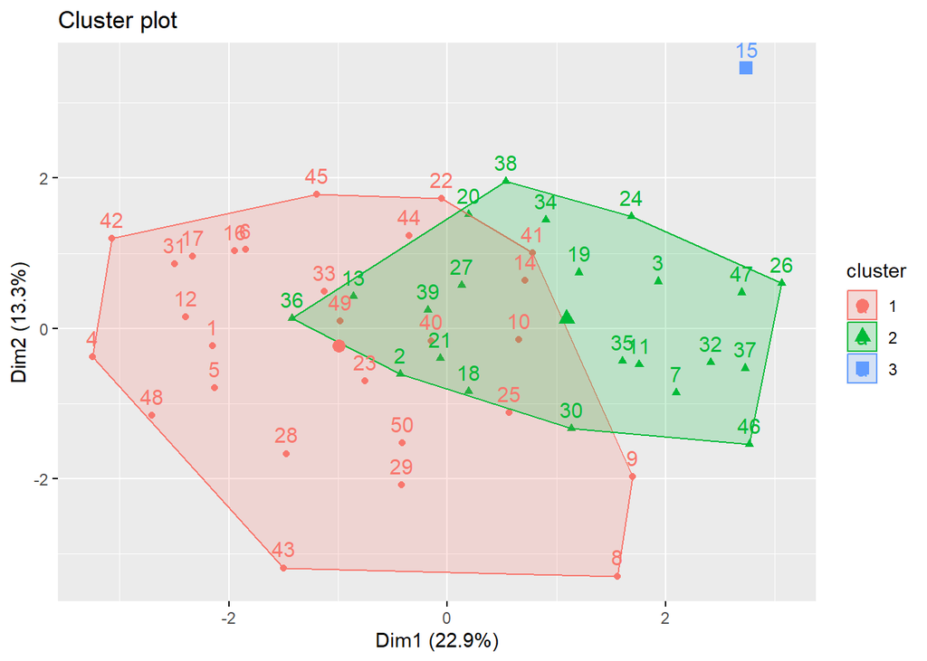

```r
# Visualize cluster
fviz_cluster(hc.cut, ellipse.type = "convex")
```

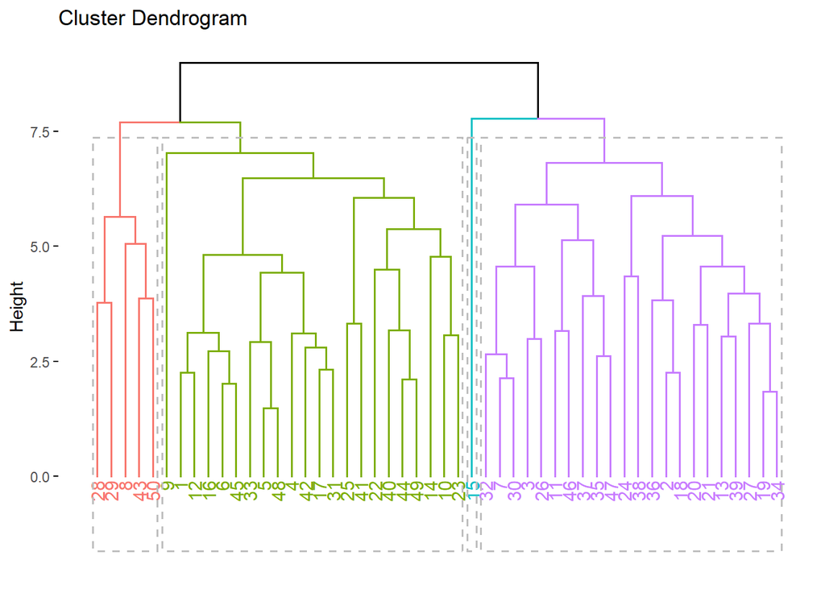

```r
set.seed(2835)
# draw a sample of 40 records from the USArrests data, so that the clustering plot will not be over crowded
idx <- sample(1:dim(dataset)[1], 50)
dataset2 <- dataset[idx, ]
## hiercrchical clustering
library(factoextra)
hc.cut <- hcut(dataset2, k = 4, hc_method = "complete") # Computes Hierarchical Clustering and Cut the Tree


# Visualize dendrogram
fviz_dend(hc.cut,rect = TRUE)  #logical value specifying whether to add a rectangle around groups.
```

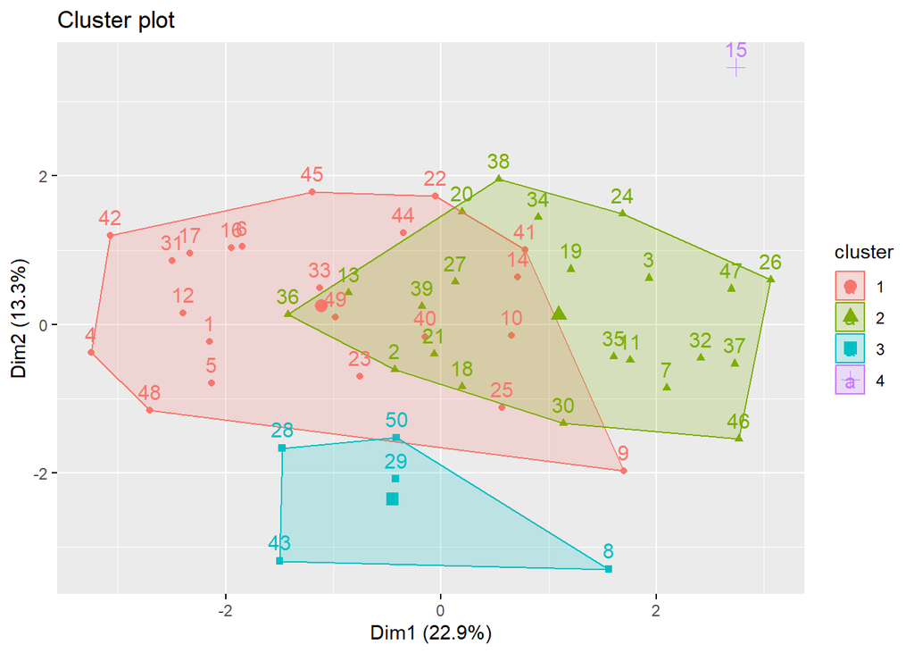

```r
# Visualize cluster
fviz_cluster(hc.cut, ellipse.type = "convex")
```

We used hierarchical clustering to see if we can get better cluster results that k-means, but since k-means gave us the least overlapping, we were able to understand or data better. We decided to use k means method instead of hierarchical since k means showed us clearer clusters. ——————————————————————————————

Validation using average silhouette for each clusters:

```r
# Set seed for reproducibility
set.seed(123)


dataset <- dataset[,-14]

# Scale the dataset (this should be done outside the loop, only once)
dataset <- scale(dataset)

# Prepare a vector to hold average silhouette widths for each k (k from 2 to 4)
avg_sil_widths <- numeric(3)

# Loop over k from 2 to 4
for (k in 2:4) {
  # Run the k-means algorithm on the dataset
  kmeans.result <- kmeans(dataset, centers = k, nstart = 25)
  # Calculate silhouette widths for each point
  sil_widths <- silhouette(kmeans.result$cluster, dist(dataset))
  # Calculate the average silhouette width
  avg_sil_widths[k-1] <- mean(sil_widths[, "sil_width"]) # corrected index k-1
}

# Print the average silhouette widths for each k
avg_sil_widths
```

```
## [1] 0.1667853 0.1160380 0.1222743
```

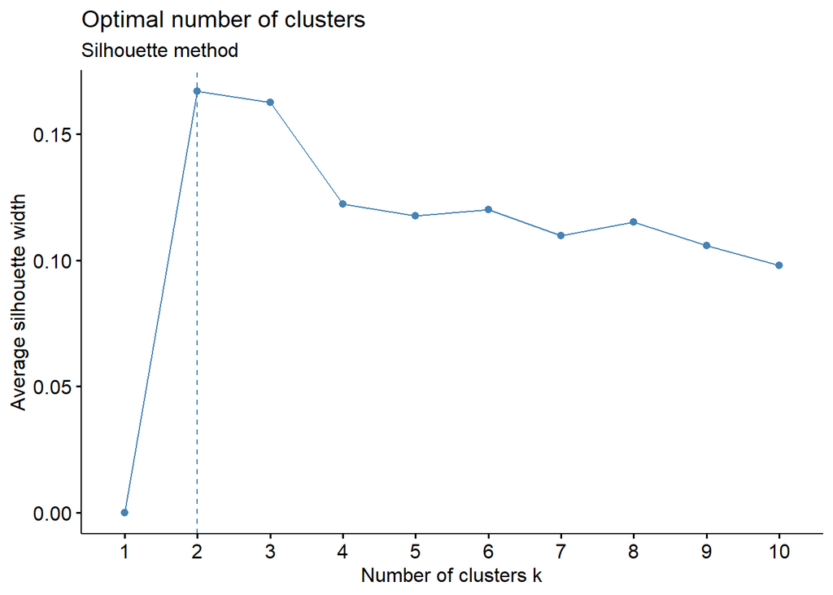

```r
# Function to compute average silhouette width
silhouette_score <- function(k){
  km <- kmeans(dataset, centers = k, nstart = 25)
  ss <- silhouette(km$cluster, dist(dataset))
  sil <- mean(ss[, 3])
  return(sil)
}

# Use silhouette method to determine the optimal number of clusters
fviz_nbclust(dataset, kmeans, method = "silhouette") +
  labs(subtitle = "Silhouette method")
```

```r
# Initialize wss for k values from 2 to 10, so it should have 9 elements
wss <- numeric(9) # Corrected to 9 to match the loop below

# Loop over k from 2 to 10
for (k in 2:10) {
  # Run the k-means algorithm on the dataset with k clusters
  kmeans.result <- kmeans(dataset, centers = k, nstart = 25)
  # Store the total within-cluster sum of squares in the wss vector
  wss[k-1] <- kmeans.result$tot.withinss # Corrected index k-1
}

# You can now plot the WSS (Elbow method) or print the WSS values
# plot(2:10, wss, type = "b", xlab = "Number of Clusters", ylab = "Within-cluster sum of squares",
#     main = "Elbow Method for Optimal Number of Clusters")
```

#silhouette width

For Clustering, we used K-means algorithm with 3 different values for K to find the optimal number of clusters. We calculated the average silhouette width for each K, and found the following outcomes: • Number of cluster(K)= 2, the average silhouette width=0.16 • Number of cluster(K)= 3, the average silhouette width=0.11 • Number of cluster(K)= 4, the average silhouette width=0.12 The model that has the optimal number of clusters is k=2 because it has the best average silhouette width and that means the objects that are in the same cluster are closer to each other and distanced from the objects in the other cluster.k=3 and k=4 don’t have the highest silhouette width values, which tells us that objects that are in the same cluster are farther from each other and less distanced from the objects in the other clusters. ——————————————————————————————————— total within-cluster sum of square(graph)

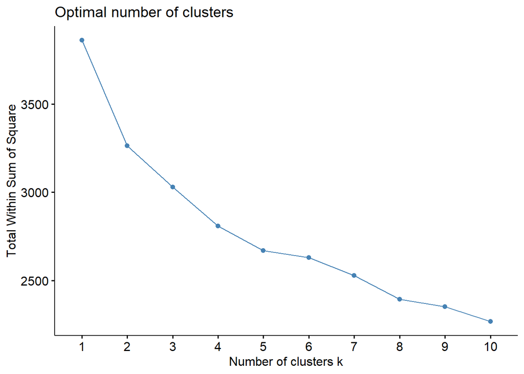

```r
fviz_nbclust(dataset, kmeans, method = "wss")
```

**#Findings**

For K=2 : The average silhouette width was 0.16, which shows us that the objects in a cluster were grouped together closely and less overlapping. Precision was 0.70 and recall was 0.72.This shows us a good capability to accurately capture instances within clusters and recognize relevant points. However, The total within-cluster sum of squares is 3264.308, which tells us that the points are far from the centroid. large distance tells us that the points are farther away from the centroid, which is not wanted for a good cluster.

For K=4: The average silhouette width was 0.12, which shows us that the objects in a cluster were not really grouped together closely and there is likely more overlapping. Precision was 0.67 and recall was 0.36.This shows us a lesser capability to accurately capture instances within clusters and recognize relevant points. However, The total within-cluster sum of squares is 2808.383, which tells us that the points are closer to the centroid. The closer the points in a cluster are to the centroid, the better. A small distance tells us that the points are closer to the centroid, which is wanted for a good cluster.

In conclusuin, Bcubed and silhouette methods show us that k=2 is the best choice for clustering, and total within-cluster sum of square was the only method that told us that k=4 is the best.But in our case,this is not accurate because low WSS is supposed to mean that the clusters don’t really overlap but in our case k=4 shows us that there is a lot of overlapping (although it has the least wss value) in the clusters and k=2 gives us the least overlapping to almost no overlapping (although it has the most wss value). so we must discard what the total within-cluster sum of square is telling us and choose the k=2 as the optimal number of clusters.

So,We finally decided that k=2 is the the optimal number of clusters since we were able to see two clear categories for our data because the clusters were seperated well (with little to no overlaps) since k=2 had the highest silhouette width. we must mention the fairly high precision and recall (0.70 and 0.72) which tells us the the model is able to accurately put the data in their correct groups.

**clustering table:**

[output not shown]

The findings and conclusion for classification were previously discussed in Final Report-classification file

## Both approaches (Classification and Clustering)were helpful for building models for our data set that can help in reaching our goal which is detecting people from heart attacks, but since our data set includes class label which is target, classification was considered the best option to predict the possibilities of having heart attack based on the attributes also the model had great accuracy.

| Refrences: |
| --- |

[1]“rstudio - ggplot2 library installation in R Studio,” Stack Overflow. https://stackoverflow.com/questions/36582347/ggplot2-library-installation-in-r-studio. [2]“boxplot function - RDocumentation,” www.rdocumentation.org. https://www.rdocumentation.org/packages/graphics/versions/3.6.2/topics/boxplot. [3]“R Documentation and manuals | R Documentation,” Rdocumentation.org, 2019. https://www.rdocumentation.org/. [4]StatQuest with Josh Starmer, “StatQuest: K-means clustering,” YouTube, 23 05, 2018. [Video]. Available: https://youtu.be/4b5d3muPQmA. [Accessed: 11, 11, 2023]. [5] [DATAtab], “Hierarchical Cluster Analysis [Simply explained],” YouTube, [Video], Published 01 26, 2023. Available: https://youtu.be/8QCBl-xdeZI. [Accessed: Access 11 11, 2023].